# PracticalML

AmaraZuffer

2/10/2020

Loading necessary libraries

```r
#imports
library(caret)
```

```r
library(lattice)
library(ggplot2)
library(rpart)
library(gbm)
```

Loading the respective datasets

The datasets used in this exercise were downloaded and accessed via the local computer. They are differentiated as traina and test sets. ##Reading data

```r
data_train <- read.csv("data/pml-training.csv")
data_test <- read.csv("data/pml-testing.csv")
dim(data_train)
```

```
## [1] 19622   160
```

```r
dim(data_test)
```

```
## [1]  20 160
```

Data Preparation

In order to use this dataset for predictions, it is quite necessary to clean and format the dataset as per the requirement.

First the variables having near zero values are removed.

```r
#removing variables with near zero values
#is.na(data_train)
nzv = nearZeroVar(data_train)
org_training_data = data_train[,-nzv]
org_testing_data = data_test[,-nzv]

dim(org_training_data)
```

```
## [1] 19622   100
```

```r
dim(org_testing_data)
```

```
## [1]  20 100
```

```r
#removing variables wiht NA values
na_vals <- sapply(org_training_data, function(x) mean(is.na(x))) >0.95
org_training_data <- org_training_data[,na_vals == FALSE]
org_testing_data <- org_testing_data[,na_vals == FALSE]
```

```r
dim(org_testing_data)
```

```
## [1] 20 59
```

```r
dim(org_training_data)
```

```
## [1] 19622    59
```

```r
#remove unrelated variables
org_training_data <- org_training_data[,8:59]
org_testing_data <- org_testing_data[,8:59]
```

```r
dim(org_training_data)
```

```
## [1] 19622    52
```

```r
dim(org_testing_data)
```

```
## [1] 20 52
```

```r
colnames(org_training_data)
```

```
##  [1] "pitch_belt"           "yaw_belt"             "total_accel_belt"
##  [4] "gyros_belt_x"         "gyros_belt_y"         "gyros_belt_z"
##  [7] "accel_belt_x"         "accel_belt_y"         "accel_belt_z"
## [10] "magnet_belt_x"        "magnet_belt_y"        "magnet_belt_z"
## [13] "roll_arm"             "pitch_arm"            "yaw_arm"
## [16] "total_accel_arm"      "gyros_arm_x"          "gyros_arm_y"
## [19] "gyros_arm_z"          "accel_arm_x"          "accel_arm_y"
## [22] "accel_arm_z"          "magnet_arm_x"         "magnet_arm_y"
## [25] "magnet_arm_z"         "roll_dumbbell"        "pitch_dumbbell"
## [28] "yaw_dumbbell"         "total_accel_dumbbell" "gyros_dumbbell_x"
## [31] "gyros_dumbbell_y"     "gyros_dumbbell_z"     "accel_dumbbell_x"
## [34] "accel_dumbbell_y"     "accel_dumbbell_z"     "magnet_dumbbell_x"
## [37] "magnet_dumbbell_y"    "magnet_dumbbell_z"    "roll_forearm"
## [40] "pitch_forearm"        "yaw_forearm"          "total_accel_forearm"
## [43] "gyros_forearm_x"      "gyros_forearm_y"      "gyros_forearm_z"
## [46] "accel_forearm_x"      "accel_forearm_y"      "accel_forearm_z"
## [49] "magnet_forearm_x"     "magnet_forearm_y"     "magnet_forearm_z"
## [52] "classe"
```

```r
colnames(org_testing_data)
```

```
##  [1] "pitch_belt"           "yaw_belt"             "total_accel_belt"
##  [4] "gyros_belt_x"         "gyros_belt_y"         "gyros_belt_z"
##  [7] "accel_belt_x"         "accel_belt_y"         "accel_belt_z"
## [10] "magnet_belt_x"        "magnet_belt_y"        "magnet_belt_z"
## [13] "roll_arm"             "pitch_arm"            "yaw_arm"
## [16] "total_accel_arm"      "gyros_arm_x"          "gyros_arm_y"
## [19] "gyros_arm_z"          "accel_arm_x"          "accel_arm_y"
## [22] "accel_arm_z"          "magnet_arm_x"         "magnet_arm_y"
## [25] "magnet_arm_z"         "roll_dumbbell"        "pitch_dumbbell"
## [28] "yaw_dumbbell"         "total_accel_dumbbell" "gyros_dumbbell_x"
## [31] "gyros_dumbbell_y"     "gyros_dumbbell_z"     "accel_dumbbell_x"
## [34] "accel_dumbbell_y"     "accel_dumbbell_z"     "magnet_dumbbell_x"
## [37] "magnet_dumbbell_y"    "magnet_dumbbell_z"    "roll_forearm"
## [40] "pitch_forearm"        "yaw_forearm"          "total_accel_forearm"
## [43] "gyros_forearm_x"      "gyros_forearm_y"      "gyros_forearm_z"
## [46] "accel_forearm_x"      "accel_forearm_y"      "accel_forearm_z"
## [49] "magnet_forearm_x"     "magnet_forearm_y"     "magnet_forearm_z"
## [52] "problem_id"
```

Seggregating Data

Here, the loaded training dataset is being divided in to training and testing.

```r
from_train <- createDataPartition(org_training_data$classe,p=0.6,list=FALSE)
train <- org_training_data[from_train,]
test <- org_training_data[-from_train,]

dim(train)
```

```
## [1] 11776    52
```

```r
dim(test)
```

```
## [1] 7846   52
```

Fitting different models to the datasets

1. Decision Tree Model

```r
library(randomForest)
D_Tree <- train(classe ~.,data=train, method='rpart')
```

```r
#prediction
D_Tree_pred <- predict(D_Tree,test)
confusionMatrix(D_Tree_pred,test$classe)
```

```
## Confusion Matrix and Statistics
##
##           Reference
## Prediction    A    B    C    D    E
##          A 2022  671  672  572  307
##          B   35  481   41  232  290
##          C  115  171  566  176  192
##          D   46  194   89  306  212
##          E   14    1    0    0  441
##
## Overall Statistics
##
##                Accuracy : 0.4864
##                  95% CI : (0.4752, 0.4975)
##     No Information Rate : 0.2845
##     P-Value [Acc > NIR] : < 2.2e-16
##
##                   Kappa : 0.3277
##
##  Mcnemar's Test P-Value : < 2.2e-16
##
## Statistics by Class:
##
##                      Class: A Class: B Class: C Class: D Class: E
## Sensitivity            0.9059  0.31686  0.41374   0.2379  0.30583
## Specificity            0.6042  0.90550  0.89904   0.9175  0.99766
## Pos Pred Value         0.4764  0.44578  0.46393   0.3613  0.96711
## Neg Pred Value         0.9417  0.84676  0.87896   0.8600  0.86455
## Prevalence             0.2845  0.19347  0.17436   0.1639  0.18379
## Detection Rate         0.2577  0.06131  0.07214   0.0390  0.05621
## Detection Prevalence   0.5409  0.13752  0.15549   0.1080  0.05812
## Balanced Accuracy      0.7551  0.61118  0.65639   0.5777  0.65174
```

As per the overall metrics, the accuracy is very low.

2)Random Forest Model

```r
RF_Model <- train(classe ~., data=train,method='rf',ntree=100)
```

```r
#prediction
RF_pred <- predict(RF_Model,test)
RF_pred_conf <- confusionMatrix(RF_pred,test$classe)
RF_pred_conf
```

```
## Confusion Matrix and Statistics
##
##           Reference
## Prediction    A    B    C    D    E
##          A 2231   26    0    0    0
##          B    1 1481   15    0    0
##          C    0    9 1346   26    5
##          D    0    0    7 1258   12
##          E    0    2    0    2 1425
##
## Overall Statistics
##
##                Accuracy : 0.9866
##                  95% CI : (0.9838, 0.989)
##     No Information Rate : 0.2845
##     P-Value [Acc > NIR] : < 2.2e-16
##
##                   Kappa : 0.9831
##
##  Mcnemar's Test P-Value : NA
##
## Statistics by Class:
##
##                      Class: A Class: B Class: C Class: D Class: E
## Sensitivity            0.9996   0.9756   0.9839   0.9782   0.9882
## Specificity            0.9954   0.9975   0.9938   0.9971   0.9994
## Pos Pred Value         0.9885   0.9893   0.9711   0.9851   0.9972
## Neg Pred Value         0.9998   0.9942   0.9966   0.9957   0.9974
## Prevalence             0.2845   0.1935   0.1744   0.1639   0.1838
## Detection Rate         0.2843   0.1888   0.1716   0.1603   0.1816
## Detection Prevalence   0.2877   0.1908   0.1767   0.1628   0.1821
## Balanced Accuracy      0.9975   0.9865   0.9889   0.9877   0.9938
```

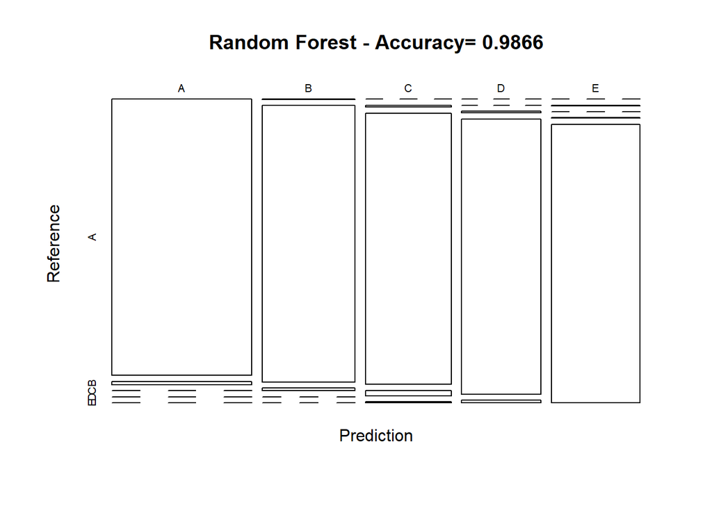

```r
#plot
plot(RF_pred_conf$table, col = RF_pred_conf$byClass,main=paste("Random Forest - Accuracy=",round(RF_pred_conf$overall['Accuracy'],4)))
```

As per the accuracy metrics this model shows an accuracy of 99% on the test set which is very good. But, there is a concern on overfitting!

3)Gradient Boost Model

```r
GB_model <- train(classe ~.,data=train ,method = 'gbm',verbose=FALSE)
GB_model$finalModel
```

```
## A gradient boosted model with multinomial loss function.
## 150 iterations were performed.
## There were 51 predictors of which 51 had non-zero influence.
```

```r
#prediction
GBM_pred <- predict(GB_model,test)

GBM_pred_accuracy <- confusionMatrix(GBM_pred, test$classe)
GBM_pred_accuracy
```

```
## Confusion Matrix and Statistics
##
##           Reference
## Prediction    A    B    C    D    E
##          A 2201   61    0    1    2
##          B   22 1400   52    2   33
##          C    7   54 1294   40   23
##          D    1    0   21 1227   21
##          E    1    3    1   16 1363
##
## Overall Statistics
##
##                Accuracy : 0.954
##                  95% CI : (0.9491, 0.9585)
##     No Information Rate : 0.2845
##     P-Value [Acc > NIR] : < 2.2e-16
##
##                   Kappa : 0.9418
##
##  Mcnemar's Test P-Value : 6.415e-13
##
## Statistics by Class:
##
##                      Class: A Class: B Class: C Class: D Class: E
## Sensitivity            0.9861   0.9223   0.9459   0.9541   0.9452
## Specificity            0.9886   0.9828   0.9809   0.9934   0.9967
## Pos Pred Value         0.9717   0.9278   0.9126   0.9661   0.9848
## Neg Pred Value         0.9944   0.9814   0.9885   0.9910   0.9878
## Prevalence             0.2845   0.1935   0.1744   0.1639   0.1838
## Detection Rate         0.2805   0.1784   0.1649   0.1564   0.1737
## Detection Prevalence   0.2887   0.1923   0.1807   0.1619   0.1764
## Balanced Accuracy      0.9874   0.9525   0.9634   0.9738   0.9710
```

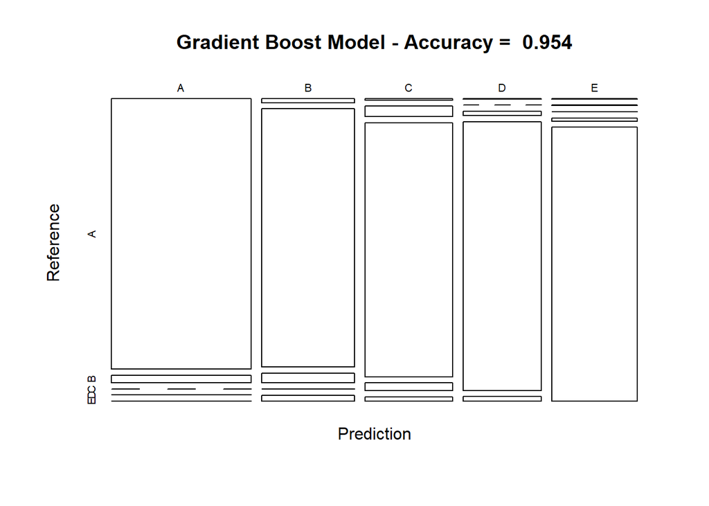

```r
#plot
plot(GBM_pred_accuracy$table, col=GBM_pred_accuracy$byClass, main=paste("Gradient Boost Model - Accuracy = ",round(GBM_pred_accuracy$overall['Accuracy'],4)))
```

Conclusion

Applying Test Data on the selected (Random Forest) model

```r
final_pred <- predict(RF_Model, org_testing_data)
final_pred
```

```
##  [1] B A B A A E D B A A B C B A E E A B B B
## Levels: A B C D E
```